# diamonds

Autogenerated data summary from dataMaid

2021-02-25 21:35:15

# Data report overview

The dataset examined has the following dimensions:

| Feature | Result |
| --- | --- |
| Number of observations | 53940 |
| Number of variables | 10 |

### Checks performed

The following variable checks were performed, depending on the data type of each variable:

|  | character | factor | labelled | haven labelled | numeric | integer | logical | Date |
| --- | --- | --- | --- | --- | --- | --- | --- | --- |
| Identify miscoded missing values | × | × | × | × | × | × |  | × |
| Identify prefixed and suffixed whitespace | × | × | × | × |  |  |  |  |
| Identify levels with < 6 obs. | × | × | × | × |  |  |  |  |
| Identify case issues | × | × | × | × |  |  |  |  |
| Identify misclassified numeric or integer variables | × | × | × | × |  |  |  |  |
| Identify outliers |  |  |  |  | × | × |  | × |

Please note that all numerical values in the following have been rounded to 2 decimals.

# Summary table

|  | Variable class | # unique values | Missing observations | Any problems? |
| --- | --- | --- | --- | --- |
| carat | numeric | 273 | 0.00 % | × |
| cut | ordered | 5 | 0.00 % |  |
| color | ordered | 7 | 0.00 % |  |
| clarity | ordered | 8 | 0.00 % |  |
| depth | numeric | 184 | 0.00 % | × |
| table | numeric | 127 | 0.00 % | × |
| price | integer | 11602 | 0.00 % |  |
| x | numeric | 554 | 0.00 % | × |
| y | numeric | 552 | 0.00 % | × |
| z | numeric | 375 | 0.00 % | × |

# Variable list

## carat

| Feature | Result |
| --- | --- |
| Variable type | numeric |
| Number of missing obs. | 0 (0 %) |
| Number of unique values | 273 |
| Median | 0.7 |
| 1st and 3rd quartiles | 0.4; 1.04 |
| Min. and max. | 0.2; 5.01 |

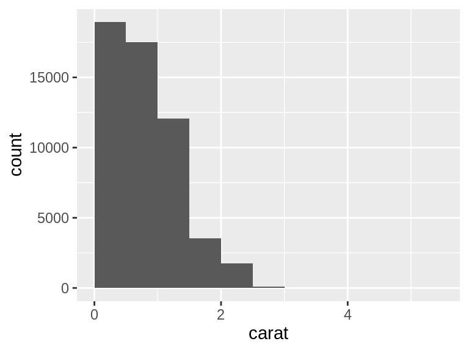

- Note that the following possible outlier values were detected: "2.47", "2.48", "2.49", "2.5", "2.51", "2.52", "2.53", "2.54", "2.55", "2.56" (36 additional values omitted).

## cut

| Feature | Result |
| --- | --- |
| Variable type | ordered |
| Number of missing obs. | 0 (0 %) |
| Number of unique values | 5 |
| Mode | "Ideal" |
| Reference category | Fair |

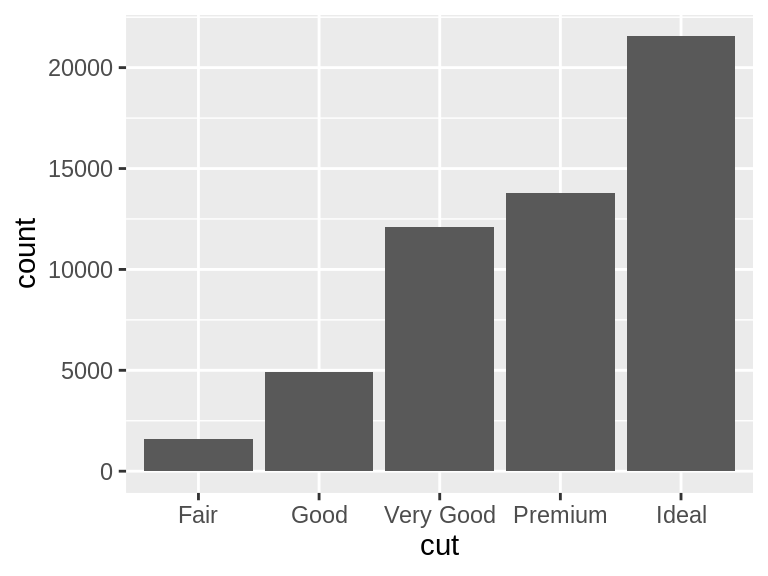

## color

| Feature | Result |
| --- | --- |
| Variable type | ordered |
| Number of missing obs. | 0 (0 %) |
| Number of unique values | 7 |
| Mode | "G" |
| Reference category | D |

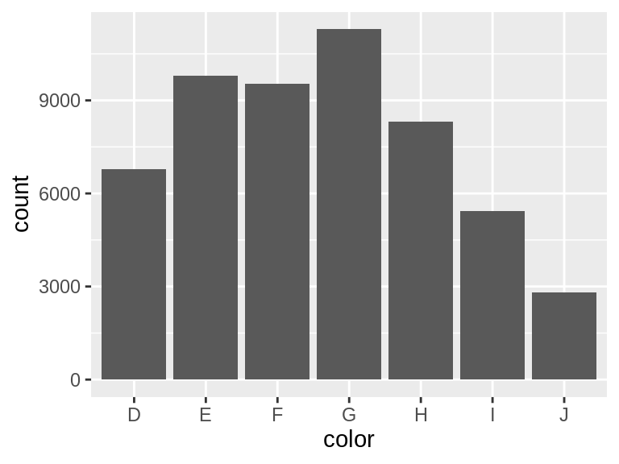

## clarity

| Feature | Result |
| --- | --- |
| Variable type | ordered |
| Number of missing obs. | 0 (0 %) |
| Number of unique values | 8 |
| Mode | "SI1" |
| Reference category | I1 |

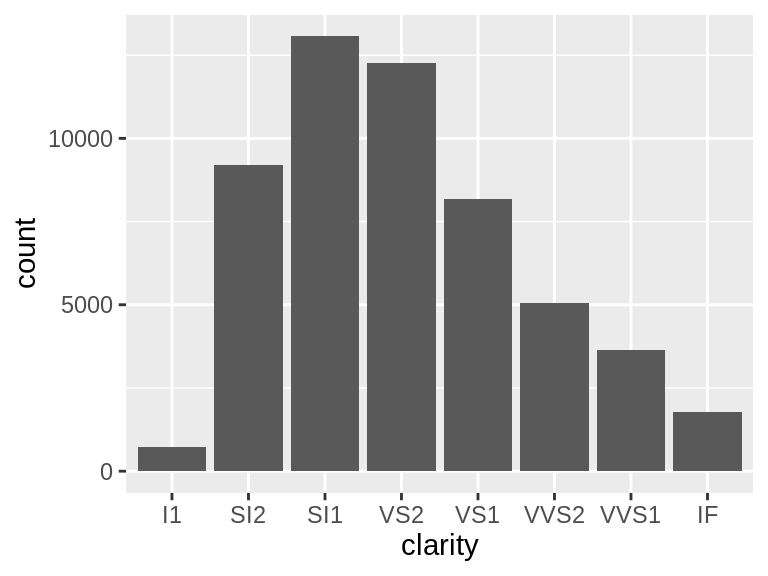

## depth

| Feature | Result |
| --- | --- |
| Variable type | numeric |
| Number of missing obs. | 0 (0 %) |
| Number of unique values | 184 |
| Median | 61.8 |
| 1st and 3rd quartiles | 61; 62.5 |
| Min. and max. | 43; 79 |

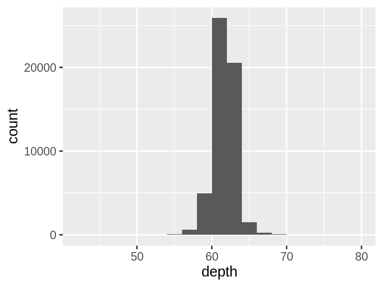

- Note that the following possible outlier values were detected: "43", "44", "50.8", "51", "52.2", "52.3", "52.7", "53", "53.1", "53.2" (114 additional values omitted).

## table

| Feature | Result |
| --- | --- |
| Variable type | numeric |
| Number of missing obs. | 0 (0 %) |
| Number of unique values | 127 |
| Median | 57 |
| 1st and 3rd quartiles | 56; 59 |
| Min. and max. | 43; 95 |

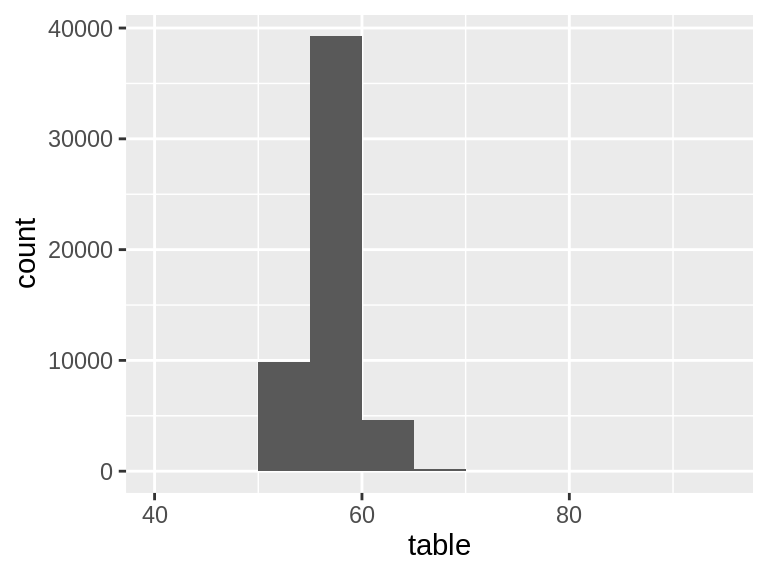

- Note that the following possible outlier values were detected: "43", "44", "49", "50", "50.1", "51", "51.6", "52", "52.4", "52.8" (18 additional values omitted).

## price

| Feature | Result |
| --- | --- |
| Variable type | integer |
| Number of missing obs. | 0 (0 %) |
| Number of unique values | 11602 |
| Median | 2401 |
| 1st and 3rd quartiles | 950; 5324.25 |
| Min. and max. | 326; 18823 |

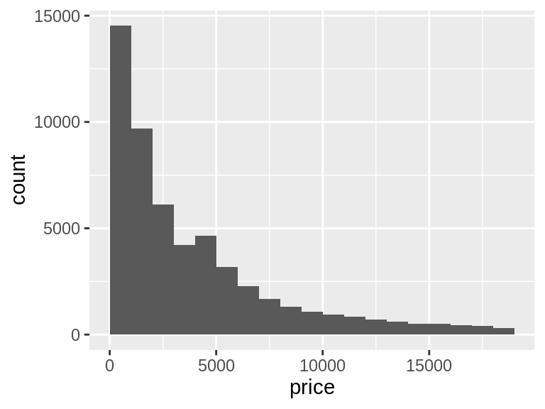

## x

| Feature | Result |
| --- | --- |
| Variable type | numeric |
| Number of missing obs. | 0 (0 %) |
| Number of unique values | 554 |
| Median | 5.7 |
| 1st and 3rd quartiles | 4.71; 6.54 |
| Min. and max. | 0; 10.74 |

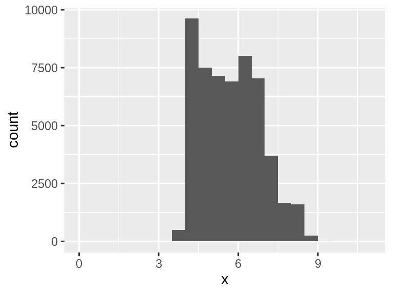

- Note that the following possible outlier values were detected: "0", "9.17", "9.23", "9.24", "9.25", "9.26", "9.3", "9.32", "9.35", "9.36" (17 additional values omitted).

## y

| Feature | Result |
| --- | --- |
| Variable type | numeric |
| Number of missing obs. | 0 (0 %) |
| Number of unique values | 552 |
| Median | 5.71 |
| 1st and 3rd quartiles | 4.72; 6.54 |
| Min. and max. | 0; 58.9 |

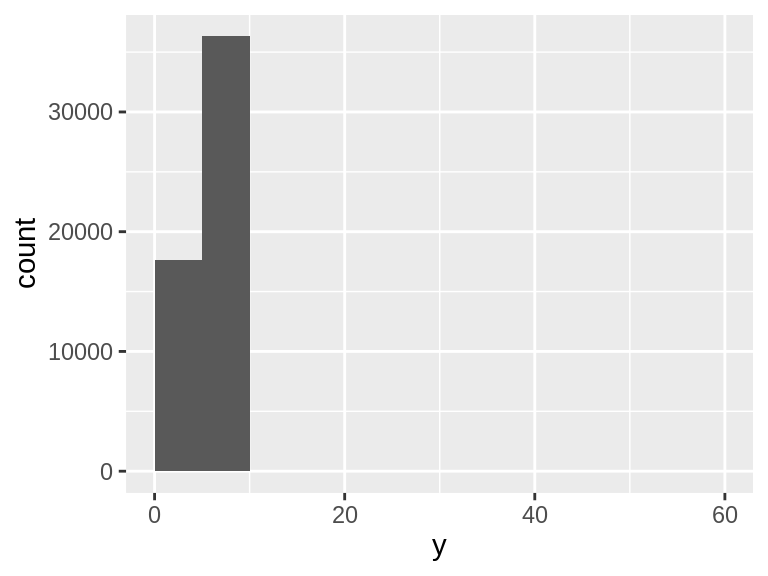

- Note that the following possible outlier values were detected: "0", "9.01", "9.02", "9.03", "9.07", "9.1", "9.13", "9.14", "9.19", "9.2" (22 additional values omitted).

## z

| Feature | Result |
| --- | --- |
| Variable type | numeric |
| Number of missing obs. | 0 (0 %) |
| Number of unique values | 375 |
| Median | 3.53 |
| 1st and 3rd quartiles | 2.91; 4.04 |
| Min. and max. | 0; 31.8 |

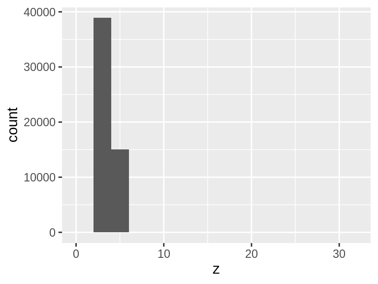

- Note that the following possible outlier values were detected: "0", "5.56", "5.57", "5.58", "5.59", "5.6", "5.61", "5.62", "5.64", "5.65" (29 additional values omitted).

Report generation information:

- Created by: Could not determine from system (username: `root`).
- Report creation time: Thu Feb 25 2021 21:35:16
- Report was run from directory: `/content`
- dataMaid v1.4.0 [Pkg: 2019-12-10 from CRAN (R 4.0.4)]
- R version 4.0.4 (2021-02-15).
- Platform: x86_64-pc-linux-gnu (64-bit)(Ubuntu 18.04.5 LTS).
- Function call: `makeDataReport(data = diamonds)`